# 基础衍生

本文适应人群：`C#` or `Python3` 基础巩固

代码裤子： https://github.com/lotapp/BaseCode

在线编程： https://mybinder.org/v2/gh/lotapp/BaseCode/master

在线预览：[http://github.lesschina.com/python/base/ext/基础衍生.html](https://github.lesschina.com/python/base/ext/基础衍生.html)

马上快期末考试了，老师蜜月也回来了，于是有了一场跨季度的复习讲课了：

## 1.Python基础语法扩展

### 1.1.if 判断条件相关

`None、""、0、[]、{}` ==> 假

`1、" "、[None,""]、{"":None}` ==> 真

小明可高兴了，前几天被打击的面目全非，这几天老师回来了，又可以大发神威了，于是抢先提交demo：

```python
# None
if None:
    print(True)
else:
    print(False)
```

```
False
```

```python
# 0为False
if 0:
    print(True)
else:
    print(False)
```

```
False
```

```python
# 空字符串
if "":
    print(True)
else:
    print(False)
```

```
False
```

```python
# 空列表为False
if []:
    print(True)
else:
    print(False)
```

```
False
```

```python
# 空字典为False
if {}:
    print(True)
else:
    print(False)
```

```
False
```

```python
# 1为True
if 1:
    print(True)
else:
    print(False)
```

```
True
```

```python
# 含空格
if " ":
    print(True)
else:
    print(False)
```

```
True
```

```python
if [None,""]:
    print(True)
else:
    print(False)
```

```
True
```

```python
if {"":None}:
    print(True)
else:
    print(False)
```

```
True
```

老师微带笑容的看了小明一眼，然后接着讲if的扩展

### 1.2.三元表达符

eg:`max = a if a > b else b`

```python
a, b = 1, 2

max = a if a > b else b

print(max)
```

```
2
```

```python
a, b, c = 1, 3, 2

max = a if a > b else b
max = max if max > c else c

print(max)
```

```
3
```

```python
# 上面的那个还有一种简写（不推荐）
a, b, c = 1, 3, 2

max = (a if a > b else b) if (a if a > b else b) > c else c

print(max)
```

```
3
```

### 1.2.字符串和编码

在`Python3.x`版本中，字符串是以`Unicode`编码的

对于单个字符的编码，Python提供了`ord()`函数获取字符的整数表示，`chr()`函数把编码转换为对应的字符

小潘对这块有所研究，把小明按在桌上然后抢先提交demo：

```python
ord('D')
```

```
68
```

```python
ord('毒')
```

```
27602
```

```python
chr(68)
```

```
'D'
```

```python
chr(27602)
```

```
'毒'
```

```python
print(ord('A'))
print(ord('Z'))

print(ord('a'))
print(ord('z'))
```

```
65
90
97
122
```

老师补充讲解道：

编码：`encode()` 解码：`decode()`

url相关的可以用：

`urllib.parse.quote()` and `urllib.parse.unquote()`

`urllib.parse.urlencode()` 可以直接对一个`key-value`进行`url`编码

```python
# encode() and decode()
name="毒逆天"

name_encode=name.encode("utf-8")

print(name_encode)

print(name_encode.decode("utf-8"))
```

```
b'\xe6\xaf\x92\xe9\x80\x86\xe5\xa4\xa9'
毒逆天
```

```python
# 需要导入urlib.parse

import urllib.parse
```

```python
test_str="淡定"

# 对字符串进行url编码和解码
test_str_enode = urllib.parse.quote(test_str)

print(test_str_enode)

# urllib.parse.quote() 解码
print(urllib.parse.unquote(test_str_enode))
```

```
%E6%B7%A1%E5%AE%9A
淡定
```

```python
# urlencode 可以直接对一个key-value进行编码

test_dict={"name":"毒逆天","age":23}

encode_str = urllib.parse.urlencode(test_dict)

print(encode_str)
print(urllib.parse.unquote(encode_str))
```

```
name=%E6%AF%92%E9%80%86%E5%A4%A9&age=23
name=毒逆天&age=23
```

### 1.3.值判断和地址判断

小明不乐意了，你个小潘总是抢我的风头，看完标题就刷刷的在黑板上写下了如下知识点：

**is 是比较两个引用是否指向了同一个对象**（`id()`得到的地址一样则相同）

**== 是比较两个对象的值是否相等**

在之前讲Dict的时候提了一下可变和不可变类型：https://www.cnblogs.com/dotnetcrazy/p/9155310.html#5.2.增加和修改

Func里面又系统的说了一下：https://www.cnblogs.com/dotnetcrazy/p/9175950.html#4.5.可变类型和不可变类型

对于可变不可变系列就不去复述了，下面再来几个案例看看 **值判断**和 **地址判断**的概念

```python
################ 可变类型 ################
```

```python
a=[1,2,3]
b=[1,2,3]

# id不一样，那is肯定不一样了
print(id(a))
print(id(b))
```

```
139727165899464
139727165725256
```

```python
# a和b是否指向同一个地址
a is b
```

```
False
```

```python
# a和b的值是否相同
a == b
```

```
True
```

```python
################ 开始变化了 ################
```

```python
# 让a指向b的地址
a=b

# a和b的id一样了
print(id(a))
print(id(b))
```

```
139727165725256
139727165725256
```

```python
# a和b是否指向同一个地址
a is b
```

```
True
```

```python
# a和b的值是否相同
a == b
```

```
True
```

```python
################ 不可变类型 ################
```

```python
a=1
b=1

# id一样
print(id(a))
print(id(b))
```

```
94592578394656
94592578394656
```

```python
a is b
```

```
True
```

```python
a == b
```

```
True
```

```python
# 但是你要注意，不是所有不可变类型都这样的

f1=1.2
f2=1.2

# 声明两个相同值的浮点型变量，查看它们的id，发现它们并不是指向同个内存地址(这点和int类型不同)
print(id(f1))
print(id(f2))
```

```
139727217917024
139727217917096
```

```python
# 这个就不一样了
# 这方面涉及Python内存管理机制，Python对int类型和较短的字符串进行了缓存
# 无论声明多少个值相同的变量，实际上都指向同个内存地址，其他的就没这福利咯～

f1 is f2
```

```
False
```

```python
f1 == f2
```

```
True
```

## 2.Python总结之for系列

老师徐徐道来：“之前说for总是零零散散的，现在基础都讲完了，来个小汇总：”

### 2.1.Base

**能够被for循环遍历的，就是可迭代的**

For基础系：https://www.cnblogs.com/dotnetcrazy/p/9102030.html#9.1.Python

```python
# 类似于for(int i=0;i<5;i++)

for i in range(5):
    print(i)
```

```
0
1
2
3
4
```

```python
#while循环一般通过数值是否满足来确定循环的条件
#for循环一般是对能保存多个数据的变量，进行遍历

name="https://pan.baidu.com/s/1weaF2DGsgDzAcniRzNqfyQ#mmd"

for i in name:
    if i=='#':
        break
    print(i,end='')#另一种写法：print("%s"%i,end="")
print('\n end ...')
```

```
https://pan.baidu.com/s/1weaF2DGsgDzAcniRzNqfyQ
 end ...
```

```python
# 你期望的结果是：i = 5

for i in range(10):
    if i == 5:
        print("i = %d" % i)
else:
    print("没有找到")
```

```
i = 5
没有找到
```

```python
# 当迭代的对象迭代完并为空时，位于else的子句将执行
# 而如果在for循环中含有break时则直接终止循环，并不会执行else子句
# 正确写法如下：

for i in range(10):
    if i == 5:
        print("i = %d" % i)
        break
else:
    print("没有找到")
```

```
i = 5
```

```python
# 遍历一个字典

test_dict={"Name":"小明","Age":23}

for k,v in test_dict.items():
    print("key:%s,value:%s"%(k,v))
```

```
key:Name,value:小明
key:Age,value:23
```

### 2.2.列表生成式

如果下面知识点还不熟悉的，看看之前讲的～列表生成式：https://www.cnblogs.com/dotnetcrazy/p/9155310.html#1.9.列表生成式

**简写**：`list(range(1, 11))` **全写**：`[x for x in range(1,11)]`

```python
list(range(1, 11))
```

```
[1, 2, 3, 4, 5, 6, 7, 8, 9, 10]
```

```python
[x for x in range(1,11)]
```

```
[1, 2, 3, 4, 5, 6, 7, 8, 9, 10]
```

```python
# 1~10的平方列表
[x*x for x in range(1,11)]
```

```
[1, 4, 9, 16, 25, 36, 49, 64, 81, 100]
```

```python
# 1~10之间的偶数
[x for x in range(1, 11) if x % 2 == 0]
```

```
[2, 4, 6, 8, 10]
```

```python
# 数学里面的全排列
[x + y for x in 'ABC' for y in 'AB']
```

```
['AA', 'AB', 'BA', 'BB', 'CA', 'CB']
```

```python
# 数学里面的坐标轴
[(x,y) for x in range(1,5) for y in range(1,4)]
```

```
[(1, 1),
 (1, 2),
 (1, 3),
 (2, 1),
 (2, 2),
 (2, 3),
 (3, 1),
 (3, 2),
 (3, 3),
 (4, 1),
 (4, 2),
 (4, 3)]
```

```python
# (x,y,z) 一般三个嵌套就上天了
[(x,y,z) for x in range(1,5) for y in range(1,4) for z in range(1,3)]
```

```
[(1, 1, 1),
 (1, 1, 2),
 (1, 2, 1),
 (1, 2, 2),
 (1, 3, 1),
 (1, 3, 2),
 (2, 1, 1),
 (2, 1, 2),
 (2, 2, 1),
 (2, 2, 2),
 (2, 3, 1),
 (2, 3, 2),
 (3, 1, 1),
 (3, 1, 2),
 (3, 2, 1),
 (3, 2, 2),
 (3, 3, 1),
 (3, 3, 2),
 (4, 1, 1),
 (4, 1, 2),
 (4, 2, 1),
 (4, 2, 2),
 (4, 3, 1),
 (4, 3, 2)]
```

### 2.3.扩展

**如果要对list实现类似C#或者java那样的下标循环怎么办？**

这块小明又有预习，于是在提交Code的同时大声说道：

Python内置的`enumerate`函数可以把一个list变成`索引-元素`对，这样就可以在for循环中同时迭代`索引和元素本身`

```python
for i, item in enumerate(['A', 'B', 'C']):
    print(i, item)
```

```
0 A
1 B
2 C
```

## 3.Python中赋值、浅拷贝、深拷贝

看到标题小明和小潘就楞了，老师当时没讲解啊，然后两个人眼巴巴的看着老师讲解：

官方文档：https://docs.python.org/3/library/copy.html

### 3.1.赋值

通过`=`来实现，就是把地址拷贝了一份，比如 `a = b`

```python
a=[1,2,2]
b = a

print(id(a))
print(id(b))
```

```
139727165518536
139727165518536
```

```python
# 再验证

a.append(3)

# 都增加了一个3，说明的确指向同一个内存地址
print(a)
print(b)
```

```
[1, 2, 2, 3]
[1, 2, 2, 3]
```

### 3.2.深拷贝deepcopy

导入`copy`模块，调用`deepcopy`方法

如果有嵌套引用的情况，直接递归拷贝

```python
import copy

a=[1,2,2]
```

```python
b=copy.deepcopy(a)

# 指向了不同的内存地址
print(id(a))
print(id(b))
```

```
139727165899080
139727165900488
```

```python
# 再验证一下

a.append(3)

# b不变，说明的确指向不同的内存地址
print(a)
print(b)
```

```
[1, 2, 2, 3]
[1, 2, 2]
```

```python
################ 开始变化了 ################
```

```python
# 之前讲了嵌套列表，我们来验证一下

a=[1,2,2]
b=[1,2,3,a]

c=copy.deepcopy(b)

# 发现地址都不一样
print(id(b))
print(id(c))
print(id(b[3]))
print(id(c[3]))
```

```
139727166586248
139727165899080
139727165725256
139727165899464
```

```python
# 直观的验证一下

a.append(666)

# 深拷贝的确是深拷贝
print(b)
print(c)
```

```
[1, 2, 3, [1, 2, 2, 666]]
[1, 2, 3, [1, 2, 2]]
```

### 3.3.浅拷贝copy

copy只是简单拷贝，如果拷贝内容里面还有引用之类的，他是不管的

```python
import copy

a=[1,2,2]
```

```python
b=copy.copy(a)

# 指向了不同的内存地址
print(id(a))
print(id(b))
```

```
139727165902088
139727165850952
```

```python
################ 开始变化了 ################
```

```python
# 之前讲了嵌套列表，我们来验证一下

a=[1,2,2]
b=[1,2,3,a]

c=copy.copy(b)

# 第一层地址不一样
print(id(b))
print(id(c))
```

```
139727165519432
139727165902088
```

```python
# 验证一下
b.append(111)

# 第一层指向的不同地址
print(b)
print(c)
```

```
[1, 2, 3, [1, 2, 2], 111]
[1, 2, 3, [1, 2, 2]]
```

```python
# 如果里面还有引用，那么就不管了
print(id(b[3]))
print(id(c[3]))
```

```
139727165725576
139727165725576
```

```python
# 验证一下
a.append(666)

# 内部引用的确没copy新地址
print(b)
print(c)
```

```
[1, 2, 3, [1, 2, 2, 666], 111]
[1, 2, 3, [1, 2, 2, 666]]
```

### 3.4.知识扩展

**如果拷贝的对象是不可变类型，不管深拷贝和浅拷贝以及赋值都是地址引用。`但当拷贝的不可变对象含有引用类型时，只有深拷贝(deepcopy)会递归复制`**

需要注意的是：Python和Net对于值类型处理是不一样的（管理方式不一样导致的）

==>`NET中值类型默认是深拷贝的，而对于引用类型，默认实现的是浅拷贝`

```python
a=(1,2,2)
b=a

print(id(a))
print(id(b))
```

```
139727165526520
139727165526520
```

```python
a=(1,2,2)
b=copy.deepcopy(a)

print(id(a))
print(id(b))
```

```
139727165846872
139727165846872
```

```python
a=(1,2,2)
b=copy.copy(a)

print(id(a))
print(id(b))
```

```
139727165526520
139727165526520
```

**扩：当拷贝的不可变对象含有引用类型时：赋值和浅拷贝不会copy，而深拷贝(deepcopy)会递归复制**

[figure not shown]

**PS：我们常用的切片相当于浅拷贝**（`copy.copy()`）

[figure not shown]

## 4.CSharp中赋值、浅拷贝、深拷贝

小明听懂了Python的深拷贝和浅拷贝后，本着学以致用的原则，写下了C#的实现：

先声明一下，本机环境是Ubuntu + NetCore，欢迎贴Code补充

### 4.1.赋值

Code：https://github.com/lotapp/BaseCode/tree/master/netcore/3_Ext/deepcopy

赋值方法和`Python`一样，直接赋值即可

```
var list1 = new List<int>() { 1, 2, 2 };
var list2 = list1;
```

```python
%%script csharp

// Python一样，直接赋值即可
var list1 = new List<int>() { 1, 2, 2 };
var list2 = list1;

// 验证一下
list1.Add(3);//我们修改一下list1，list2也就跟着就改变了

foreach (var item in list1)
{
    Console.Write(item + " ");
}
Console.WriteLine();
foreach (var item in list2)
{
    Console.Write(item + " ");
}
```

```
1 2 2 3
1 2 2 3
```

### 4.2值类型默认深拷贝

NetCore深拷贝相关的[官方文档](https://docs.microsoft.com/zh-cn/dotnet/api/system.collections.generic.list-1.copyto?view=netcore-2.1) `public void CopyTo (T[] array);`

简单类型用**最简单的方式**就能实现深拷贝了：

官方的CopyTo在这里和这个效果一样，但是比较麻烦，这边就不贴了（Code里面贴了）

```
var list3 = new List<int>() { 1, 2, 2 };
var list4 = new List<int>(list3);

// 验证一下
list3.Add(3);
foreach (var item in list3)
{
    Console.Write(item + " ");
}
Console.WriteLine();
foreach (var item in list4)
{
    Console.Write(item + " ");
}
```

结果：

```
1 2 2 3
1 2 2
```

### 4.3.引用类型默认浅拷贝

**对于`List<T>`再复杂点的，上面的方式就变成浅拷贝了：(类似于Python的Copy.Copy)**

官方的CopyTo在这里和这个效果一样，但是比较麻烦，这边就不贴了（Demo里面贴了）

定义一个Student

```
public partial class Student
{
    public string Name { get; set; }
    public int Age { get; set; }

    public override string ToString()
    {
        return $"Name:{Name},Age:{Age}";
    }
}
```

浅拷贝Demo：

```
var list5 = new List<Student>(){
    new Student { Name = "小张", Age = 22 },
    new Student { Name = "小明", Age = 23 }
    };
var p = new Student() { Name = "小潘", Age = 23 };
list5.Add(p);

// 浅拷贝一份
var list6 = new List<Student>(list5);

// 浅拷贝测试
// 我们修改一下list5，list6没有跟着改变，说明第一层的地址的确不一样
list5.Add(new Student() { Name = "小胖", Age = 24 });
// 当我们修改小潘同学的年龄时，大家都变了，说明真的只是浅拷贝
p.Age = 24;

foreach (var item in list5)
{
    Console.WriteLine(item);
}
Console.WriteLine("=============");
foreach (var item in list6)
{
    Console.WriteLine(item);
}
```

结果：

```
Name:小张,Age:22
Name:小明,Age:23
Name:小潘,Age:24
Name:小胖,Age:24
=============
Name:小张,Age:22
Name:小明,Age:23
Name:小潘,Age:24
```

### 4.4.简单方式实现深拷贝

对于`List<T>`的深拷贝场景，其实项目中还是蛮常见的,那深拷贝怎么搞呢？

先来一个简单的实现方式，需要`T`实现`ICloneable`接口才行：

定义一个Person类

```
public partial class Person : ICloneable
{
    public string Name { get; set; }
    public int Age { get; set; }

    //实现ICloneable的Clone方法
    public object Clone()
    {
        return base.MemberwiseClone();//调用父类方法即可
    }

    public override string ToString()
    {
        return $"Name:{Name},Age:{Age}";
    }
}
```

给`List<T>`定义一个扩展方法：（温馨提醒：扩展方法所在的类必须是static Class哦）

```
public static partial class ListExt
{
    // 只要T实现了ICloneable接口就可以了
    public static IEnumerable<T> DeepCopy<T>(this IEnumerable<T> list) where T : ICloneable
    {
        return list.Select(item => (T)item.Clone()).ToList();
    }
}
```

来个调用加验证：

```
#region 引用类型深拷贝-简单实现方式

var oldList = new List<Person>(){
    new Person(){Name="小明",Age=23},
    new Person(){Name="小张",Age=22},
};
var xiaoPan = new Person() { Name = "小潘", Age = 23 };
oldList.Add(xiaoPan);

var newList = oldList.DeepCopy();

//测试
oldList.Add(new Person() { Name = "小胖", Age = 23 });
xiaoPan.Age = 24;

foreach (var item in oldList)
{
    Console.WriteLine(item);
}
Console.WriteLine("========");
foreach (var item in newList)
{
    Console.WriteLine(item);
}

#endregion
```

结果：

```
Name:小明,Age:23
Name:小张,Age:22
Name:小潘,Age:24
Name:小胖,Age:23
========
Name:小明,Age:23
Name:小张,Age:22
Name:小潘,Age:23
```

### 4.5.序列化方式实现深拷贝（常用）

利用`System.Runtime.Serialization`序列化与反序列化实现深拷贝

先定义一个Teacher类（别忘记加 **`Serializable`** 的标签）

```
[Serializable]
public partial class Teacher
{
    public string Name { get; set; }
    public int Age { get; set; }

    public override string ToString()
    {
        return $"Name:{Name},Age:{Age}";
    }
}
```

添加一个扩展方法：

```
public static partial class ListExt
{
    // 利用System.Runtime.Serialization序列化与反序列化实现深拷贝
    public static T DeepCopy2<T>(this T obj)
    {
        using (var stream = new MemoryStream())
        {
            var formatter = new BinaryFormatter();
            formatter.Serialize(stream, obj);
            stream.Seek(0, SeekOrigin.Begin);
            return (T)formatter.Deserialize(stream);
        }
    }
}
```

调用：

```
#region 引用类型深拷贝-序列化实现

var oldTestList = new List<Teacher>(){
    new Teacher(){Name="小明",Age=23},
    new Teacher(){Name="小张",Age=22},
};
var s = new Teacher() { Name = "小潘", Age = 23 };
oldTestList.Add(s);

var newTestList = oldTestList.DeepCopy2();

//测试
oldTestList.Add(new Teacher() { Name = "小胖", Age = 23 });
s.Age = 24;

foreach (var item in oldTestList)
{
    Console.WriteLine(item);
}
Console.WriteLine("========");
foreach (var item in newTestList)
{
    Console.WriteLine(item);
}

#endregion
```

结果：

```
Name:小明,Age:23
Name:小张,Age:22
Name:小潘,Age:24
Name:小胖,Age:23
========
Name:小明,Age:23
Name:小张,Age:22
Name:小潘,Age:23
```

因为主要是说Python，Net只是简单提一下，这边就先到这里了

不尽兴可以看看[这篇文章](https://www.cnblogs.com/zhili/p/DeepCopy.html)，讲得还是挺全面的

我们接着来对比学习～

## 5.Python生成器

一看到标题小明又懵圈了，但是看到大家好像都知道的样子心想道：“我是不是又睡过一节课啊？”

之前有讲列表生成式，这边说说生成器

通过列表生成式，我们可以简单并直接的创建一个列表，但是当数据有一定的规律而且又很大的时候，使用列表就有点浪费资源了

如果列表元素可以按照某种算法推算出来，这样就不必创建完整的list，从而节省大量的资源

### 5.1.简单方式

**在Python中，这种一边循环一边计算的机制，称为生成器：`generator`**

先看一个简单的生成器案例：（**只要把一个列表生成式的`[]`改成`()`** ，就创建了一个`generator`了）

```python
# 列表生成式
[x for x in range(10)]
```

```
[0, 1, 2, 3, 4, 5, 6, 7, 8, 9]
```

```python
# 生成器写法（Python2.x系列是用xrange）
(x for x in range(10))
```

```
<generator object <genexpr> at 0x7f14c413cb48>
```

遍历方式可以用之前的`for`循环来遍历（推荐）

也可以用`next()`或者`__next__()`方法来遍历。【C#是用`MoveNext`】

`generator`保存的是算法，每次调用`next(xxx)`或者`__next__()`，就计算出下一个元素的值，直到计算到最后一个元素

当没有更多的元素时，抛出`StopIteration`的异常

最新的Python3.7在这方面有所优化：https://www.python.org/dev/peps/pep-0479

```python
g=(x for x in range(10))

# for来遍历（推荐）
for i in g:
    print(i)
```

```
0
1
2
3
4
5
6
7
8
9
```

```python
g=(x for x in range(10))

print(next(g))
print(next(g))
print(next(g))
print(next(g))
print(next(g))
print(g.__next__()) #通过__next__也一样取下一个
print(next(g))
print(next(g))
print(next(g))
print(next(g))
print(next(g))
print(next(g))
```

```
0
1
2
3
4
5
6
7
8
9
```

```
---------------------------------------------------------------------------
StopIteration                             Traceback (most recent call last)
<ipython-input-72-9897a9148994> in <module>()
     11 print(next(g))
     12 print(next(g))
---> 13 print(next(g))
     14 print(next(g))

StopIteration:
```

### 5.2.yield方式

如果推算的算法比较复杂，用类似列表生成式的for循环无法实现时，还可以用函数来实现

这时候就需要用到`yield`了，像最经典的斐波拉契数列，这次用一波生成器来对比实现下：

```python
# 递归方式：求第30个数是多少

# 1、1、2、3、5、8、13、21、34...
def fib(n):
    if n == 1 or n == 2:
        return 1
    else:
        return fib(n - 1) + fib(n - 2)

fib(30)
```

```
832040
```

```python
# 在讲yield方式之前先用循环实现一下

def fibona(max):
    n, a, b = 0, 0, 1
    while n < max:
        print(b)
        a, b = b, a + b
        n = n + 1

fibona(30)
```

```
1
1
2
3
5
8
13
21
34
55
89
144
233
377
610
987
1597
2584
4181
6765
10946
17711
28657
46368
75025
121393
196418
317811
514229
832040
```

```python
# for循环实现

def fibona(n):
    a, b = 0, 1
    # [0,n)
    for i in range(n):
        print(b)
        a, b = b, a + b

fibona(30)
```

```
1
1
2
3
5
8
13
21
34
55
89
144
233
377
610
987
1597
2584
4181
6765
10946
17711
28657
46368
75025
121393
196418
317811
514229
832040
```

`a, b = b, a + b` 之前交换两数的时候提过

这个相当于==>

```
temp_tuple = (b, a + b)
a = temp_tuple[0]
b = temp_tuple[1]
```

要把`fibona`函数变成`generator`，只需要把`print(b)`改为`yield b`就可以了：

**`generator`在执行过程中，遇到`yield`就中断，下次又继续执行到`yield`停下了，一直到最后**

生成器的特点：

1. 节约内存
2. 迭代到下一次的调用时，所使用的参数都是第一次所保留下的（所有函数调用的参数都是第一次所调用时保留的，而不是新创建的）

```python
# 改成生成器比较简单，直接换输出为yield

def fibona(n):
    a, b = 0, 1
    # [0,n)
    for i in range(n):
        yield b
        a, b = b, a + b
```

```python
# 看看是不是生成器
g = fibona(30)

g
```

```
<generator object fibona at 0x7f14c40efd58>
```

```python
# 遍历输出（基本上都会用for来遍历）
for i in g:
    print(i)
```

```
1
1
2
3
5
8
13
21
34
55
89
144
233
377
610
987
1597
2584
4181
6765
10946
17711
28657
46368
75025
121393
196418
317811
514229
832040
```

对于函数改成的generator来说，遇到return语句或者执行到函数体最后一行语句，就是结束generator的循环的时候

小明总结如下：

1. **在Python中，这种一边循环一边计算的机制称为生成器：generator**
2. **每一个生成器都是一个迭代器（迭代器不一定是生成器）**
3. **如果一个函数包含yield关键字，这个函数就会变为一个生成器**
4. **生成器并不会一次返回所有结果，而是每次遇到yield关键字后返回相应结果，并保留函数当前的运行状态，等待下一次的调用**
5. **由于生成器也是一个迭代器，那么它就支持next用方法来获取下一个值（我们平时用for来遍历它）**

推荐一篇文章，总结的很全了：（[yield用法总结](https://www.cnblogs.com/python-life/articles/4549996.html)）

### 5.3.扩展之～`send(msg)`方法：

其实`__next__()`和`send()`在一定意义上作用是相似的，区别是`send()`可以传递yield表达式的值进去

而`__next__()`不 能传递特定的值。我们可以看做`x.__next__()` 和 `x.send(None)` 作用是一样的

```python
# 来个案例：
def test_send(n):
    for i in range(n):
        tmp = yield i
        print(tmp)


g = test_send(5)

g
```

```
<generator object test_send at 0x7f14c40efdb0>
```

```python
# 定义一个列表
test_list = []

# 把第一次yield的值放在列表中
test_list.append(g.__next__())

# 把list传给tmp并打印（可以理解为把表达式右边的 yield i 暂时换成了 test_list）
# out的内容是yield返回的值
g.send(test_list)
```

```
[0]
```

```
1
```

```python
# 以防你们看不懂，来个简单案例
# 你传啥print(tmp)就给你打印啥
g.send("你好啊")
```

```
你好啊
```

```
2
```

注意一种情况，`generator`刚启动的时候，要么不传，要么只能传`None`

解决：要么一开始`send(None)`要么一开始先调用一下`__next()__` or `next()`

```python
# 注意一种情况，generator刚启动的时候，要么不传，要么只能传None
def test_send(n):
    for i in range(n):
        tmp = yield i
        print(tmp)


g = test_send(5)
g.send("dog") # TypeError: can't send non-None value to a just-started generator
```

```
---------------------------------------------------------------------------
TypeError                                 Traceback (most recent call last)
<ipython-input-82-2e891aa5dd81> in <module>()
      7
      8 g = test_send(5)
----> 9 g.send("dog") # TypeError: can't send non-None value to a just-started generator

TypeError: can't send non-None value to a just-started generator
```

```python
# 解决：要么一开始send(None)要么一开始先调用一下__next()__ or next()
def test_send(n):
    for i in range(n):
        tmp = yield i
        print(tmp)


g = test_send(5)
g.send(None)
```

```
0
```

```python
g.send("dog")
```

```
dog
```

```
1
```

扩：C#在遍历`generator`的时候也是先调一下`MoveNext`方法

```
while (tmp.MoveNext())
{
    Console.WriteLine(tmp.Current);
}
```

### 5.4.扩展之～`return`和`break`的说明

在一个`generator`函数中，如果没有`return`则默认执行至函数完毕

如果在执行过程中`return`或者`break`则直接抛出`StopIteration`终止迭代

```python
# break案例
def test_send(n):
    for i in range(n):
        if i==2:
            break
        yield i

g = test_send(5)
for i in g:
    print(i)
```

```
0
1
```

```python
# return案例
def test_send(n):
    for i in range(n):
        if i==2:
            return "i==2"
        yield i

g = test_send(5)
for i in g:
    print(i)
```

```
0
1
```

**用`for`循环调用`generator`时，发现拿不到`generator`的`return`语句的返回值**

**如果想要拿到返回值，必须捕获`StopIteration`错误，返回值包含在`StopIteration的value`中**

```python
# 上面return的返回值怎么拿呢？

g = test_send(5)

while True:
    try:
        tmp = g.__next__()
        print(tmp)
    except StopIteration as ex:
        print(ex.value)
        break # 一定要加break，别忘了你在死循环里呢
```

```
0
1
i==2
```

### 5.5.扩展之～协程`yield`实现多任务调度

这个场景还是很常见的，比如C#的单线程实现多任务用的就可以使用yield

再比如**生产消费**这个经典案例：（[参考](https://www.cnblogs.com/fangyuan1004/p/4571304.html)）

**生产者生产消息后，直接通过yield跳转到消费者开始执行，待消费者执行完毕后，切换回生产者继续生产**

Python对协程的支持是通过generator实现的

在generator中，我们不但可以通过for循环来迭代，还可以不断调用`__next__()`获取由`yield`语句返回的下一个值。

因为Python的`yield`**不但可以返回一个值，它还可以接收调用者发出的参数**(通过`send`方法),所以就happy了

我们举个简单的demo来看看：

```python
def consumer():
    while True:
        tmp = yield
        # !None就变成真了
        if not tmp:
            return
        print("消费者:",tmp)
```

```python
# 创建消费者
c = consumer()
# 启动消费者
c.send(None)
# 生产数据，并提交给消费者
c.send("小明")
c.send("小潘")
# 生产结束，通知消费者结束，抛出StopIteration异常
c.send(None) # 使用c.close()可以避免异常
```

```
消费者: 小明
消费者: 小潘
```

```
---------------------------------------------------------------------------
StopIteration                             Traceback (most recent call last)
<ipython-input-89-bcc0083d4089> in <module>()
      7 c.send("小潘")
      8 # 生产结束，通知消费者结束，抛出StopIteration异常
----> 9 c.send(None) # 使用c.close()可以避免异常

StopIteration:
```

**执行流程**：

1. 创建协程对象（消费者）后，必须使用`send(None)`或`__next__()`启动
2. 协程在执行yield后让出执行绪，等待消息
3. 调用方发送`send(msg)`消息，协程恢复执行，将接收到的数据保存并执行后续流程
4. 再次循环到yield，协程返回前面的处理结果，并再次让出执行绪
5. 直到关闭或被引发异常

补全demo：

```python
def consumer():
    status = ""
    while True:
        tmp = yield status
        if not tmp:
            print("消费者已经睡觉了...")
            return
        print("消费者：获得商品%s号..." % tmp)
        status = "ok"


def produce(c):
    # 启动消费者
    c.send(None)
    for i in range(1, 3):
        print("生产者：出产商品%s号..." % i)
        # 生产商品，并提交给消费者
        status = c.send(i)
        print("生产者：生产者消费状态: %s" % status)
    # c.send(None) 执行这个会引发StopIteration
    c.close()  # 使用close就可以避免了(手动关闭生成器函数，后面的调用会直接返回StopIteration异常)


# 创建消费者
c = consumer()
produce(c)
```

```
生产者：出产商品1号...
消费者：获得商品1号...
生产者：生产者消费状态: ok
生产者：出产商品2号...
消费者：获得商品2号...
生产者：生产者消费状态: ok
```

```python
# 更多可以查看帮助文档
def test():
    yield
help(test())
```

```
Help on generator object:

test = class generator(object)
 |  Methods defined here:
 |  __del__(...)
 |  __getattribute__(self, name, /)
 |      Return getattr(self, name).
 |  __iter__(self, /)
 |      Implement iter(self).
 |  __next__(self, /)
 |      Implement next(self).
 |  __repr__(self, /)
 |      Return repr(self).
 |  close(...)
 |      close() -> raise GeneratorExit inside generator.
 |  send(...)
 |      send(arg) -> send 'arg' into generator,
 |      return next yielded value or raise StopIteration.
 |  throw(...)
 |      throw(typ[,val[,tb]]) -> raise exception in generator,
 |      return next yielded value or raise StopIteration.
 |  ----------------------------------------------------------------------
 |  Data descriptors defined here:
 |  gi_code
 |  gi_frame
 |  gi_running
 |  gi_yieldfrom
 |      object being iterated by yield from, or None
```

## 6.Python迭代器

看到迭代器小明老高兴了，心想着一会写个C#版的觉得可以收获一大群眼球～

### 6.1.判断是否可迭代

在说迭代器前先说下**可迭代(Iterable)**（yield基础点我）：

在Python中，能通过for循环遍历的都是可以迭代的，比如 **`str、tuple、list、dict、set、生成器`**等等

也可以通过 **`isinstance(xxx,Iterable)`** 方法判断一下是否迭代：

```python
from collections import Iterable
```

```python
isinstance("mmd",Iterable)
```

```
True
```

```python
isinstance((1,2),Iterable)
```

```
True
```

```python
isinstance([],Iterable)
```

```
True
```

```python
isinstance({},Iterable)
```

```
True
```

```python
isinstance((x for x in range(10)),Iterable)
```

```
True
```

```python
isinstance(1,Iterable)
```

```
False
```

### 6.2.判断是否是迭代器

迭代器是一定可以迭代的，怎么判断是迭代器呢？

可以使用`next`方法的或者通过`isinstance(xxx,Iterator)`

```python
a=[1,2,3]

next(a)
```

```
---------------------------------------------------------------------------
TypeError                                 Traceback (most recent call last)
<ipython-input-99-f5f8ac9a8550> in <module>()
      1 a=[1,2,3]
      2
----> 3 next(a)

TypeError: 'list' object is not an iterator
```

```python
from collections import Iterator
```

```python
isinstance([],Iterator)
```

```
False
```

```python
isinstance((x for x in range(10)),Iterator)
```

```
True
```

### 6.3.`Iterable` 转 `Iterator`

生成器都是`Iterator`对象，但`list、dict、str`虽然是`Iterable`，却不是`Iterator`

把`list、dict、str`等`Iterable`变成`Iterator`可以使用**`iter()`**函数：

```python
iter(a)
```

```
<list_iterator at 0x7f14c40a3da0>
```

```python
isinstance(iter([]),Iterator)
```

```
True
```

```python
isinstance(iter({}),Iterator)
```

```
True
```

Python的`Iterator`对象表示的是一个数据流，`Iterator`对象可以被`next()`or`__next__()`函数调用并不断返回下一个数据,直到没有数据时抛出`StopIteration`错误

可以把这个数据流看做是一个有序序列，但我们却不能提前知道序列的长度，只能不断通过`next`函数实现按需计算下一个数据，所以`Iterator`的计算是惰性的，只有在需要返回下一个数据时它才会计算。

`Iterator`甚至可以表示一个无限大的数据流，而`list`等则不行

小明总结了一下老师讲解的知识点：

1. **可以`for`循环的对象都是`Iterable`类型**
2. **可以使用`next()`or`__next__()`函数的对象都是`Iterator`类型**
3. **集合数据类型如list、dict、str等是`Iterable`，可以通过`iter()`函数获得一个`Iterator`对象**

## 7.CSharp迭代器

乘着下课的时间，小明跑到黑板前，心想：“又到了C#的时候了，看我来收播一大群眼球～”，然后开始了他的个人秀：

其实**迭代器（`iterator`）**就是为了更简单的创建枚举器（`enumerator`）和可枚举类型（`enumerator type`）的方式

### 7.1.`IEnumerator` 和 `IEnumerable`

通俗话讲：

**能不能`foreach`就看你遍历对象有没有实现`IEnumerable`，就说明你是不是一个`可枚举类型`（`enumerator type`）**

```
public interface IEnumerable
{
    IEnumerator GetEnumerator();
}
```

**是不是个枚举器（`enumerator`）就看你实现了`IEnumerator`接口没**

```
public interface IEnumerator
{
    object Current { get; }

    bool MoveNext();

    void Reset();
}
```

**最明显的区别：它们两个遍历方式不一样**

```
// 枚举器遍历
var tmp = FibonaByIEnumerator(30);
while (tmp.MoveNext())
{
    Console.WriteLine(tmp.Current);
}
// 可枚举类型遍历
foreach (var item in FibonaByIEnumerable(30))
{
    Console.WriteLine(item);
}
```

这个我们在2年前就说过，这边简单提一下（[官方文档](https://docs.microsoft.com/zh-cn/dotnet/api/system.collections.ienumerator?view=netcore-2.1)）([Demo](https://github.com/lotapp/BaseCode/tree/master/netcore/3_Ext/Enumerator))

MyEnumerator文件：

```
public class MyEnumerator : IEnumerator
{
    /// <summary>
    /// 需要遍历的数组
    /// </summary>
    private string[] array;
    /// <summary>
    /// 有效数的个数
    /// </summary>
    private int count;
    public MyEnumerator(string[] array, int count)
    {
        this.array = array;
        this.count = count;
    }

    /// <summary>
    /// 当前索引（线moveNext再获取index，用-1更妥）
    /// </summary>
    private int index = -1;
    public object Current
    {
        get
        {
            return array[index];
        }
    }
    /// <summary>
    /// 移位
    /// </summary>
    /// <returns></returns>
    public bool MoveNext()
    {
        if (++index < count)
        {
            return true;
        }
        return false;
    }
    /// <summary>
    /// 重置
    /// </summary>
    public void Reset()
    {
        index = -1;
    }
}
```

MyArray.cs文件

```
public partial class MyArray
{
    /// <summary>
    /// 数组容量
    /// </summary>
    private string[] array = new string[4];
    /// <summary>
    /// 数组元素个数
    /// </summary>
    private int count = 0;
    /// <summary>
    /// 当前数组的长度
    /// </summary>
    public int Length
    {
        get
        {
            return count;
        }
    }

    /// <summary>
    /// 添加元素
    /// </summary>
    /// <param name="str"></param>
    /// <returns></returns>
    public MyArray Add(string str)
    {
        //要溢出的时候扩容
        if (count == array.Length)
        {
            string[] newArray = new string[2 * array.Length];
            array.CopyTo(newArray, 0);
            array = newArray;//array重新指向
        }
        array[count++] = str;
        return this;
    }

    /// <summary>
    /// 移除某一项
    /// </summary>
    /// <param name="i"></param>
    /// <returns></returns>
    public MyArray RemoveAt(int i)
    {
        for (int j = i; j < count - 1; j++)
        {
            array[j] = array[j + 1];
        }
        count--;//少了一个元素所以--
        return this;
    }

    /// <summary>
    /// 索引器
    /// </summary>
    /// <param name="index"></param>
    /// <returns></returns>
    public string this[int index]
    {
        get
        {
            return array[index];
        }
        set
        {
            array[index] = value;
        }
    }
}
```

MyArrayExt.cs文件:

```
public partial class MyArray: IEnumerable
{
    /// <summary>
    /// 枚举器方法
    /// </summary>
    /// <returns></returns>
    public IEnumerator GetEnumerator()
    {
        return new MyEnumerator(this.array, this.count);
    }
}
```

调用:

```
static void Main(string[] args)
{
    MyArray array = new MyArray();
    array.Add("~").Add("这").Add("是").Add("一").Add("个").Add("测").Add("试").Add("。").RemoveAt(0).RemoveAt(3).RemoveAt(6);
    for (int i = 0; i < array.Length; i++)
    {
        Console.Write(array[i]);
    }
    Console.WriteLine();
    foreach (var item in array)
    {
        Console.Write(item);
    }
}
```

结果:

```
这是一测试
这是一测试
```

### 7.2.yield方式

小明看着班里女生羡慕的眼神，得意的强调道：

注意一下，C#是用`yield return xxx`，Python是用`yield xxx`关键字

还记得开头说的那句话吗？（[yield官方文档](https://docs.microsoft.com/zh-cn/dotnet/csharp/language-reference/keywords/yield)）

> 其实迭代器（iterator）就是为了更简单的创建枚举器（enumerator）和可枚举类型（enumerator type）的方式

如果**枚举器和可枚举类型**还是不理解（[举个例子](https://github.com/lotapp/BaseCode/tree/master/netcore/3_Ext/IteratorDemo)）就懂了：（从遍历方式就看出区别了）

定义一个斐波拉契函数，返回可枚举类型

```
/// <summary>
/// 返回一个可枚举类型
/// </summary>
public static IEnumerable<int> FibonaByIEnumerable(int n)
{
    int a = 0;
    int b = 1;
    for (int i = 0; i < n; i++)
    {
        yield return b;
        (a, b) = (b, a + b);
    }
}
```

调用：

```
foreach (var item in FibonaByIEnumerable(30))
{
    Console.WriteLine(item);
}
```

定义一个斐波拉契函数，返回一个枚举器

```
/// <summary>
/// 返回一个枚举器
/// </summary>
public static IEnumerator<int> FibonaByIEnumerator(int n)
{
    int a = 0;
    int b = 1;
    for (int i = 0; i < n; i++)
    {
        yield return b;
        (a, b) = (b, a + b);
    }
}
```

调用一下：

```
var tmp = FibonaByIEnumerator(30);
while (tmp.MoveNext())
{
    Console.WriteLine(tmp.Current);
}
```

利用`yield`轻轻松松就创建了`枚举器和可枚举类型`

以上面那个MyArray的案例来说，有了yield我们代码量大大简化：（Demo）

MyArray.cs

```
public partial class MyArray
{
    /// <summary>
    /// 数组容量
    /// </summary>
    private string[] array = new string[4];
    /// <summary>
    /// 数组元素个数
    /// </summary>
    private int count = 0;
    /// <summary>
    /// 当前数组的长度
    /// </summary>
    public int Length
    {
        get
        {
            return count;
        }
    }

    /// <summary>
    /// 添加元素
    /// </summary>
    /// <param name="str"></param>
    /// <returns></returns>
    public MyArray Add(string str)
    {
        //要溢出的时候扩容
        if (count == array.Length)
        {
            string[] newArray = new string[2 * array.Length];
            array.CopyTo(newArray, 0);
            array = newArray;//array重新指向
        }
        array[count++] = str;
        return this;
    }

    /// <summary>
    /// 移除某一项
    /// </summary>
    /// <param name="i"></param>
    /// <returns></returns>
    public MyArray RemoveAt(int i)
    {
        for (int j = i; j < count - 1; j++)
        {
            array[j] = array[j + 1];
        }
        array[count - 1] = string.Empty;//add 干掉移除的数组
        count--;//少了一个元素所以--
        return this;
    }

    /// <summary>
    /// 索引器
    /// </summary>
    /// <param name="index"></param>
    /// <returns></returns>
    public string this[int index]
    {
        get
        {
            return array[index];
        }
        set
        {
            array[index] = value;
        }
    }
}
```

MyArrayExt.cs

```
public partial class MyArray : IEnumerable
{
    /// <summary>
    /// 枚举器方法
    /// </summary>
    /// <returns></returns>
    public IEnumerator GetEnumerator()
    {
        return MyEnumerator();
    }
    /// <summary>
    /// 通过yield快速实现
    /// </summary>
    /// <returns></returns>
    public IEnumerator<string> MyEnumerator()
    {
        foreach (var item in this.array)
        {
            yield return item;
        }
    }
}
```

然后就行了，MyEnumerator都不用你实现了：

```
MyArray array = new MyArray();
array.Add("~").Add("这").Add("是").Add("一").Add("个").Add("测").Add("试").Add("。").RemoveAt(0).RemoveAt(3).RemoveAt(6);
for (int i = 0; i < array.Length; i++)
{
    Console.Write(array[i]);
}
Console.WriteLine();
foreach (var item in array)
{
    Console.Write(item);
}
```

结果：

```
这是一测试
这是一测试
```

做个 [demo](https://github.com/lotapp/BaseCode/tree/master/netcore/3_Ext/TestBreak) 测试下:

```
public static IEnumerable<int> GetValue()
{
    for (int i = 0; i < 5; i++)
    {
        yield return i;
        if (i == 2)
        {
            yield break;
        }
    }
}
```

调用:

```
static void Main(string[] args)
{
    foreach (var item in GetValue())
    {
        Console.WriteLine(item);
    }
}
```

输出:

```
0
1
2
```

## 8.闭包

### 8.1.Python闭包

又到了上课时间，小明灰溜溜的跑回座位，听老师讲起了闭包的知识：

函数方面还有不懂的可以看之前讲的文档：[Function Base](https://www.cnblogs.com/dotnetcrazy/p/9175950.html)

**函数除了可以[接受函数作为参数](https://www.cnblogs.com/dotnetcrazy/p/9175950.html#4.3.匿名函数)外，还可以把函数作为结果值返回**（有点类似于C++里面的函数指针了）

来看一个可变参数求和的例子：

```python
def slow_sum(*args):
    def get_sum():
        sum = 0
        for i in args:
            sum += i
        return sum

    return get_sum  # 返回函数引用地址（不加括号）

a = slow_sum(1, 2, 3, 4, 5)# 返回get_sum函数的引用
print(a)# 看看引用地址
print(a())# a() 这时候才是调用get_sum()函数
```

```
<function slow_sum.<locals>.get_sum at 0x7f57783b6268>
15
```

其实上面一个案例就是闭包(`Closure`)了，来个定义：

**在函数内部再定义一个函数，并且这个函数用到了外边函数的变量**(`参数`或者`局部变量`)，**那么将这个函数以及用到的一些变量称之为闭包**

通俗点说就是：`内部函数使用了外部函数作用域里的变量了，那这个内部函数和它用到的变量就是个闭包`

注意：当我们调用`slow_sum()`时，**每次调用都会返回一个新的函数**（相同的参数也一样）

```python
a = slow_sum(1, 2, 3, 4)
b = slow_sum(1, 2, 3, 4)

a is b

# a()和b()的调用结果互不影响
```

```
False
```

**由于闭包引用了外部函数的局部变量，则外部函数的局部变量没有及时释放，所以也容易消耗内存**

so ==> **`除非你真正需要它,否则不要使用闭包`**

**返回函数尽量不要引用任何循环变量，或者后续会发生变化的变量（容易出错）**

看着小明一脸懵圈的样子，老师说道：

新讲的知识点一般都不太容易快速消化，我们再来看个闭包的好处就理解了：

比如现在我们要根据公式来求解，以`y=ax+b`为例，传统方法解决：

```python
# 定义一个y=ax+b的函数公式
def get_value(a, b, x):
    return a * x + b
```

```python
# 每次调用都得传 a,b
print(get_value(2, 1, 1))
print(get_value(2, 1, 2))
print(get_value(2, 1, 3))
print(get_value(2, 1, 4))
```

```
3
5
7
9
```

每次调用都得额外传`a、b`的值

就算使用**偏函数**来简化也不合适（毕竟已经是一个新的函数了）：

```python
from functools import partial

new_get_value = partial(get_value, 2, 1)

print(new_get_value(1))
print(new_get_value(2))
print(new_get_value(3))
print(new_get_value(4))
print(new_get_value(5))
```

```
3
5
7
9
11
```

简单总结`functools.partial`的作用就是：

> **把一个函数的某些参数设置默认值，返回一个新的函数，然后调用新函数就免得你再输入重复参数了**

而这时候使用闭包就比较合适了，而且真的是封装了一个通用公式了

a，b的值你可以任意变来生成新的公式，而且公式之间还不干扰，以 **`y=ax²+bx+c`**为例：

```python
def quadratic_func(a, b, c):
    """y=ax²+bx+c"""

    def get_value(x):
        return a * x * x + b * x + c

    return get_value
```

```python
# 来个简单的：x^2+1
f1 = quadratic_func(1, 0, 1)

print(f1(0))
print(f1(1))
print(f1(2))
print(f1(3))
print(f1(4))
print(f1(5))
```

```
1
2
5
10
17
26
```

```python
# 可能不太形象，我们画个图看看：

import matplotlib.pyplot as plt # 导入matplotlib的pyplot模块
```

```
[-10, -9, -8, -7, -6, -5, -4, -3, -2, -1, 0, 1, 2, 3, 4, 5, 6, 7, 8, 9, 10]
[101, 82, 65, 50, 37, 26, 17, 10, 5, 2, 1, 2, 5, 10, 17, 26, 37, 50, 65, 82, 101]
```

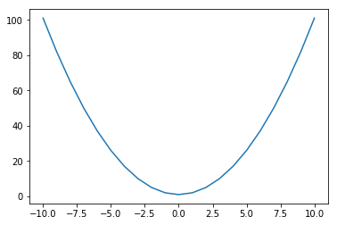

```python
# 生成x和y的值
x_list = list(range(-10, 11))
y_list = [x * x + 1 for x in x_list]

print(x_list)
print(y_list)

# 画图
plt.plot(x_list, y_list)
# 显示图片
plt.show()
```

```python
# 再来个简单的：x^2-1
f2 = quadratic_func(1, 0, -1) # 相互之间不干扰

print(f2(0))
print(f2(1))
print(f2(2))
print(f2(3))
print(f2(4))
print(f2(5))
```

```
-1
0
3
8
15
24
```

### 8.2.CSharp闭包

听完闭包老师就下课了，说什么明天接着闭包讲啥装饰器的。

小明一愣一愣的，然后就屁颠的跑黑板前讲起了C#版本的闭包：

先看看怎么定义一个闭包，和Python一样，用个求和函数举例：（**返回一个匿名函数**）

```
// 有返回值就用Func，没有就用Action
public static Func<int> SlowSum(params int[] args)
{
    return () =>
    {
        int sum = 0;
        foreach (var item in args)
        {
            sum += item;
        }
        return sum;
    };
}
```

调用：

```
static void Main(string[] args)
{
    var f1 = SlowSum(1, 2, 3, 4, 5);
    Console.WriteLine(f1);
    Console.WriteLine(f1());
}
```

结果：(从结果可以看到，f1是一个函数，等你调用f1()才会求和)

```
System.Func`1[System.Int32]
15
```

接着讲 ～ 以上面的 **`y=ax²+bx+c`**为例，C#实现：

```
// 以上面的 y=ax²+bx+c 为例，C#实现：
public static Func<double, double> QuadraticFunc(double a, double b, double c)
{
    return x => a * x * x + b * x + c; // 返回一个匿名函数
}
```

调用：

```
static void Main(string[] args)
{
    var func = QuadraticFunc(1, 0, 1);

    Console.WriteLine(func(0));
    Console.WriteLine(func(1));
    Console.WriteLine(func(2));
    Console.WriteLine(func(3));
    Console.WriteLine(func(4));
    Console.WriteLine(func(5));
}
```

结果：

```
1
2
5
10
17
26
```

`Func<double,double>`不理解就看看定义就懂了：`public delegate TResult Func<in T, out TResult>(T arg);`

这部分不是很难，简单提一下知识点即可。如果你想深究可以==> **([点](https://www.cnblogs.com/HQFZ/p/4903400.html) [点](https://www.cnblogs.com/happyframework/p/3421754.html) [点](https://kb.cnblogs.com/page/111231))**

在收获满满一箩筐眼球后，小明拍拍屁股去了新开的饭店大吃一顿了...

写在最后：还有一些内容没写，估计过几天又有一篇叫 **“基础拓展”** 的文章了，为啥不一起写完呢？

其实逆天也想写完，真写完文章又被叫做长篇大论一百页了 #^_^# 行了，听取大家意见，不写那么长的文章，下次见～